# Classifying Iight-Lifting Execution Quality with Accelerometer Data

Kernel236

2025-09-14

## Data cleaning

I removed non-predictive metadata (IDs/username/timestamps..), dropped predictors with >95% missingness and near-zero variance. This reduces noise and leakage risk without sacrificing signal.

```r
# Read dataset
train_coort <-read.csv(here::here("./data/pml-training.csv"))
test_coort <-read.csv(here::here("./data/pml-testing.csv"))

#rRemouve meta variable not uselful fo rthe models
train_coort <- train_coort |>
  select(-c(X, user_name, raw_timestamp_part_1, raw_timestamp_part_2, cvtd_timestamp, new_window, num_window))

test_coort <- test_coort |>
  select(-c(X, user_name, raw_timestamp_part_1, raw_timestamp_part_2, cvtd_timestamp, new_window, num_window, problem_id))

#NearzeroVar
nzv <- nearZeroVar(train_coort[, -153]) # saveMetrics = FALSE return just indiex for column with low variance
nzv_test <- nearZeroVar(test_coort)

train_coort <- train_coort[,-c(nzv)]
test_coort <- test_coort[,-c(nzv_test)]
# Remove columns with ≥95% missing values
na_threshold <- 0.95
train_coort <- train_coort[, colMeans(is.na(train_coort)) < na_threshold]
test_coort <- test_coort[, colMeans(is.na(test_coort)) < na_threshold]

X_train <- train_coort[,-ncol(train_coort)]
Y_train <- train_coort[,ncol(train_coort)]
```

## Cross Validation and Model Fitting

```r
set.seed(123)

ctrl <- trainControl(
  method = "cv",
  number = 5,
  savePredictions = "final",
  classProbs = TRUE
)
```

### Random Forest (RF) and Gradient Boosting (GBM)

I fit a Random Forest as a strong non-parametric baseline. RF handles nonlinearities/interaction and is robust to noisy predictors

```r
set.seed(123)

n_cores <- detectCores() # DETECT NUMBER OF CORES
cl <- makeCluster(n_cores -8)
registerDoParallel(cl) # ACTIVE PARALLEL COMPUT ON N - 8 CORE

fit_rf <- train(x = X_train, y = Y_train, method = "rf", trControl = ctrl, tuneLength = 5, metric = "Accuracy")
saveRDS(fit_rf, "../models/fit_rf.rds")

fit_gbm <- train(x = X_train, y = Y_train, method = "gbm", trControl = ctrl, ) #GBM MODEL
saveRDS(fit_rf, "../models/fit_gbm.rds")

stopCluster(cl) #STOP MultiCORE
registerDoSEQ() # RETURN TO 1 by one core
```

### Model rationale

I compared a robust tree-ensemble baseline (Random Forest) with a gradient boosting model (GBM). Ensembles typically perform Ill on noisy, tabular sensor data and are insensitive to feature scaling.

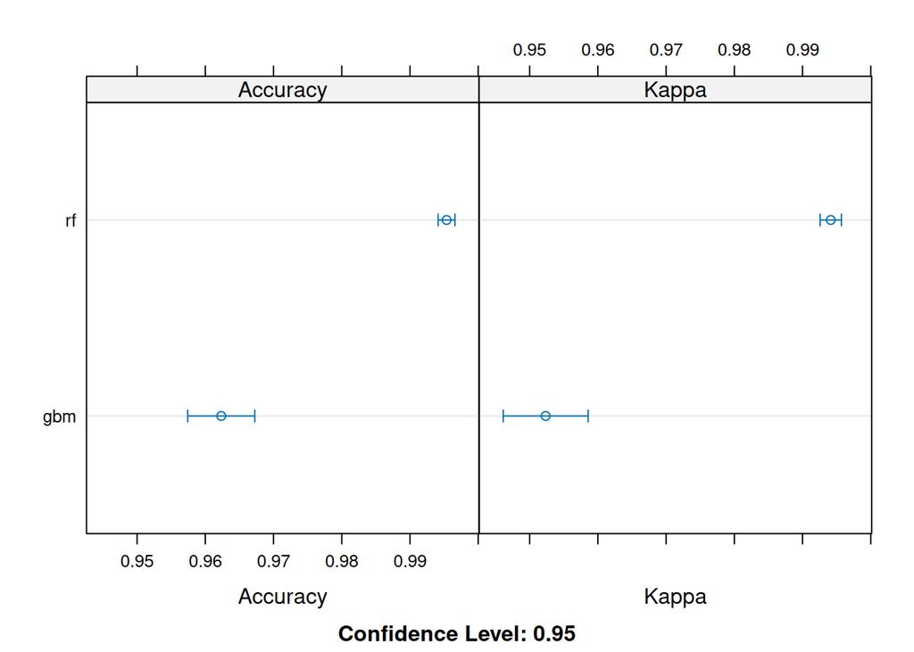

```r
res <- resamples(list(rf = fit_rf, gbm = fit_gbm))
dotplot(res)
```

```r
fit_rf
```

```
## Random Forest
##
## 19622 samples
##    52 predictor
##     5 classes: 'A', 'B', 'C', 'D', 'E'
##
## No pre-processing
## Resampling: Cross-Validated (5 fold)
## Summary of sample sizes: 15698, 15697, 15698, 15698, 15697
## Resampling results across tuning parameters:
##
##   mtry  Accuracy   Kappa
##    2    0.9940373  0.9924572
##   14    0.9953623  0.9941336
##   27    0.9939863  0.9923929
##   39    0.9916931  0.9894923
##   52    0.9881257  0.9849787
##
## Accuracy was used to select the optimal model using the largest value.
## The final value used for the model was mtry = 14.
```

```r
fit_gbm
```

```
## Stochastic Gradient Boosting
##
## 19622 samples
##    52 predictor
##     5 classes: 'A', 'B', 'C', 'D', 'E'
##
## No pre-processing
## Resampling: Cross-Validated (5 fold)
## Summary of sample sizes: 15697, 15698, 15698, 15698, 15697
## Resampling results across tuning parameters:
##
##   interaction.depth  n.trees  Accuracy   Kappa
##   1                   50      0.7527267  0.6865615
##   1                  100      0.8217311  0.7742983
##   1                  150      0.8541437  0.8153824
##   2                   50      0.8566920  0.8183865
##   2                  100      0.9059223  0.8809303
##   2                  150      0.9324741  0.9145500
##   3                   50      0.8969016  0.8694758
##   3                  100      0.9424117  0.9271276
##   3                  150      0.9623383  0.9523475
##
## Tuning parameter 'shrinkage' was held constant at a value of 0.1
##
## Tuning parameter 'n.minobsinnode' was held constant at a value of 10
## Accuracy was used to select the optimal model using the largest value.
## The final values used for the model were n.trees = 150, interaction.depth =
##  3, shrinkage = 0.1 and n.minobsinnode = 10.
```

In 5 K-fold Cross validation the RF model show a better Accuracy and Kappa with a very tiny 95% CI

### Features Importance

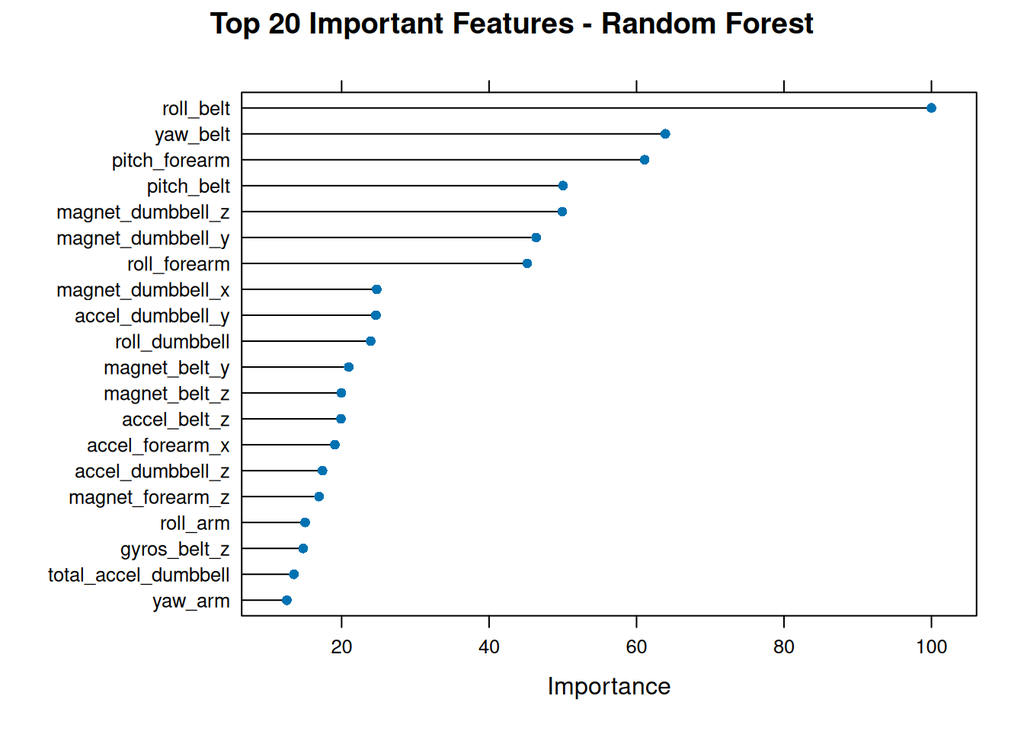

```r
varImp_rf <- varImp(fit_rf)

plot(varImp_rf, top = 20, main = "Top 20 Important Features - Random Forest")
```

## Model Comparison and Expected Error

We trained two models (Random Forest and Gradient Boosting Machine) using 5-fold cross-validation.

- Random Forest achieved an accuracy of 99,6%, corresponding to an expected out-of-sample error of ~0,4%.
- GBM achieved an accuracy of 96%, corresponding to an expected out-of-sample error of ~4%.

Based on these results, Random Forest was selected as the final model, since it provides higher accuracy and lower expected error.

## Test cases (20)

```r
pred_rf <- predict(fit_rf, test_coort)
write.csv(pred_rf, file = "../report/pred_rd.csv", row.names = FALSE)
```